# Case Model Classification - Part 2 (R)

## Modelagem

### Objetivos do projeto: desenvolver um modelo que estime a propensão de um cliente aceitar as ofertas dos produtos nos próximos 30 dias

### Metodologia:

1. Primeiramente, transformou-se variáveis categóricas em fatores no R. Como não se sabe o que significa de fato boa parte das variáveis, optou-se por assumir que tais variáveis binárias (com respostas 1 e 0) são categóricas incluindo variável answer (resposta), carregando-as no R como fatores. Além disso, a coluna id_category que possui valores inteiros de 0 a 5, também foi transformada em fator, já que entende-se que cada número representa uma categoria.
1. Após esse passo, retirou-se coluna id da base, pois esta serve apenas como identificador do cliente e não remete a nenhuma característica útil do cliente para a predição no modelo.
1. A seguir, uma semente foi definida e separou-se a base em dois conjuntos: treino (80% da base com 738194 registros) e teste (20% da base com 184548), para que o desempenho do modelo consiga ser testado atraves da validação cruzada.
1. Com bases treino e teste definidas, inicia-se o processo de modelagem utilizando variações de tipos de modelo, com o intuito de encontrar algum método que melhor defina o evento e seja capaz de prevê-lo de forma mais assertiva.
1. A partir de um erro baixo, começa-se a alterar parâmetros de tuning para se tentar obter ganho de predição no método do modelo escolhido.

**Obs:** como este é um problema de classificação, é importante citar que para alguns modelos necessita-se escoher uma taxa de corte em relação a probabilidade de chance da resposta ser 1 ou 0. Para isso, uma função que testa diversos cortes e retorna o que possui maior taxa de acerto foi criada e utilizada.

#### Autor: Vinicius Maia

#### Fazendo preparações de dados iniciais

Inicia-se o codigo utilizando arquivo csv gerado a partir do tratamento das bases feitas no jupyter "1 - Case Itaú - Análise exploratória.ipynb". A base gerada chama-se Base_modelo.csv

```r
df <- read.csv("Base_modelo.csv")

# Transformando dados categóricos em factors no R
df$answer <- as.factor(df$answer)
df$id_category <- as.factor(df$id_category)
df$var1 <- as.factor(df$var1)
for(i in c(17:length(colnames(df))-1)){
  df[,i] <- as.factor(df[,i])
}

# Retirando coluna de id
df=subset(df, select=-c(id))


# Separando amostras de treino e teste
n <- nrow(df)
set.seed(1)
ids <- sample(1:n, round(0.80*n))
treino <- df[ids,]
teste <- df[-ids,]
```

```r
# Tamanho de cada amostra
print(nrow(teste))
print(nrow(treino))
```

```
[1] 184548
[1] 738194
```

```r
# Função para obter melhor valor de corte e respectivo erro
escolhe_corte <- function(probs, real, plotar = FALSE) {
  corte <- seq(0, 1, 0.02)
  erro <- numeric()
  for(i in 1:length(corte)){
    predicao <- as.integer(probs > corte[i])

    if(is.numeric(real)){
      erro[i] <- mean((predicao - real)^2)
    }
    else if(is.factor(real)){
      erro[i] <- mean((predicao != real))
    }

  }
  if(plotar){
    plot(corte, erro, type = "l")
    abline(v=corte[which.min(erro)], col="red")
  }

  return(c(corte = corte[which.min(erro)], erro = min(erro)))
}
```

```r
# Criando DataFrame de Comparação
resultados <- data.frame(metodo = character(), erro = numeric(), corte = numeric(),
                         stringsAsFactors = F)
```

### Regressao Logística

```r
# Fazendo fit da função
logistic_model <- glm(answer ~ .,family="binomial", data = treino)
summary(logistic_model)
```

```
Call:
glm(formula = answer ~ ., family = "binomial", data = treino)

Deviance Residuals:
     Min        1Q    Median        3Q       Max
-2.38452  -0.00010  -0.00006   0.76543   1.79835

Coefficients:
               Estimate Std. Error z value Pr(>|z|)
(Intercept)  -8.579e-01  3.924e-02 -21.860  < 2e-16 ***
timestamp     4.339e-04  3.647e-05  11.898  < 2e-16 ***
id_category1  7.372e-03  1.042e-02   0.708 0.479254
id_category2  3.594e-02  1.028e-02   3.495 0.000474 ***
id_category3 -3.148e-02  1.149e-02  -2.739 0.006168 **
id_category4 -2.699e-02  4.915e-02  -0.549 0.582972
id_category5  2.926e-03  7.014e-02   0.042 0.966726
start_date    1.973e-04  1.283e-05  15.378  < 2e-16 ***
var11        -3.819e+01  4.406e+01  -0.867 0.386047
var0          2.107e-06  3.019e-07   6.979 2.97e-12 ***
var2          1.912e+01  2.203e+01   0.868 0.385541
var3          5.782e-03  2.720e-04  21.256  < 2e-16 ***
var4         -5.890e-03  5.488e-04 -10.732  < 2e-16 ***
var5         -1.284e-02  1.464e-03  -8.773  < 2e-16 ***
var6         -1.587e-01  2.576e-03 -61.609  < 2e-16 ***
var7         -8.357e-03  3.713e-04 -22.507  < 2e-16 ***
var8         -2.573e-02  2.292e-03 -11.226  < 2e-16 ***
var9         -1.097e-03  1.865e-03  -0.588 0.556268
var101        1.371e-01  1.239e-02  11.066  < 2e-16 ***
var111       -3.041e-02  1.223e-02  -2.486 0.012931 *
var121       -9.240e-02  1.297e-02  -7.123 1.06e-12 ***
var131        2.201e-01  1.329e-02  16.562  < 2e-16 ***
var141       -6.422e-02  1.203e-02  -5.336 9.48e-08 ***
var151       -5.890e-02  1.329e-02  -4.433 9.30e-06 ***
var161        1.579e-01  1.590e-02   9.928  < 2e-16 ***
var171       -9.245e-02  1.269e-02  -7.286 3.19e-13 ***
var181        3.490e-02  1.213e-02   2.877 0.004011 **
var191       -7.142e-02  1.552e-02  -4.602 4.19e-06 ***
var201       -2.888e-01  1.664e-02 -17.359  < 2e-16 ***
var211        6.589e-02  3.627e-02   1.817 0.069282 .
var221        1.941e-01  1.480e-02  13.113  < 2e-16 ***
```

[output cut: 11 more lines]

```
var341        1.504e-01  1.291e-02  11.650  < 2e-16 ***
var351        1.586e-01  1.191e-02  13.319  < 2e-16 ***
var361        2.455e-02  1.474e-02   1.665 0.095820 .
var371       -2.721e-02  1.702e-02  -1.599 0.109903
var38         2.190e-02  1.925e-04 113.751  < 2e-16 ***
---
Signif. codes:  0 '***' 0.001 '**' 0.01 '*' 0.05 '.' 0.1 ' ' 1

(Dispersion parameter for binomial family taken to be 1)

    Null deviance: 1023299  on 738193  degrees of freedom
Residual deviance:  575622  on 738147  degrees of freedom
AIC: 575716

Number of Fisher Scoring iterations: 18
```

```
    corte      erro
0.5400000 0.1860925
```

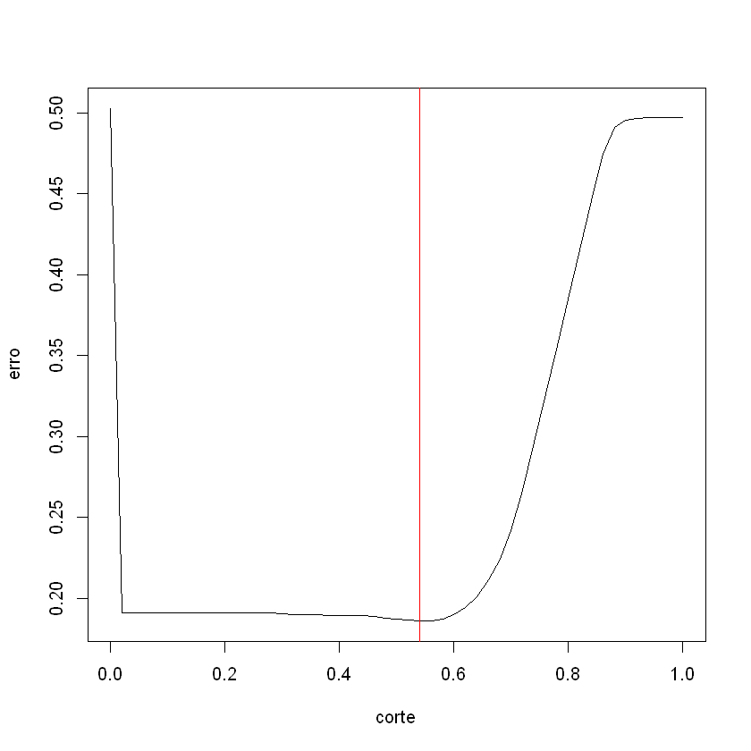

```r
# Testando modelo
pred_logistico <- predict(logistic_model, newdata = teste, type="response")

temp <- escolhe_corte(pred_logistico, teste$answer, plotar = T)

resultados[nrow(resultados)+1, ] = c("Logistico", temp[2], temp[1])
print(temp)
```

```r
# Erro de logistica
print(resultados)
```

```
     metodo              erro corte
1 Logistico 0.186092507098424  0.54
```

### Regressão Logística com Seleção

#### Utilizando Stepwise

Stepwise é uma variação do método Bestsubset Selection (diminuição do número de variáveis para aquelas que tem mais poder preditivo ao problema) com a vatangem de gerar um custo computacional menor. Isso ocorre, pois não são testadas todas as variações de subconjuntos. Os subconjuntos são utilizados apenas para a adição de uma variável (a que for mais relevante) em cada iteração.

O método utilizado para escolha de variáveis e a que produz um menor valor de RSS.

```r
#install.packages('leaps')
```

```r
library(leaps)
```

```r
# função para previsão de best subsets
predict.regsubsets <- function(object, newdata, id,...){
  form <- as.formula(object$call[[2]])
  matriz <- model.matrix(form, newdata)
  coeficientes <- coef(object, id = id)

  return(matriz[, names(coeficientes)] %*% coeficientes)

}
```

Colocando como máximo numero de combinações em 200, apenas para garantir que todas as combinações sejam testadas. So existem 46 combinações de variáveis preditoras na base.

```r
mod_stepf <- regsubsets(answer ~ ., data = treino, nvmax = 200, method = "forward")
```

```r
summary(mod_stepf)
```

```
Subset selection object
Call: regsubsets.formula(answer ~ ., data = treino, nvmax = 200, method = "forward")
46 Variables  (and intercept)
             Forced in Forced out
timestamp        FALSE      FALSE
id_category1     FALSE      FALSE
id_category2     FALSE      FALSE
id_category3     FALSE      FALSE
id_category4     FALSE      FALSE
id_category5     FALSE      FALSE
start_date       FALSE      FALSE
var11            FALSE      FALSE
var0             FALSE      FALSE
var2             FALSE      FALSE
var3             FALSE      FALSE
```

[output cut: 272 more lines]

Aplicando nos valores preditos pelos coeficientes escolhidos a equação da regressão logistica

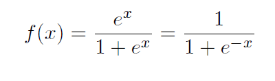

```r
resumo_stepf <- summary(mod_stepf)
coef(mod_stepf , id = which.min(resumo_stepf$rss))

# Fazendo predict do teste com  coeficientes de menor valor de rss obtido no resumo_stepf
pred <- predict.regsubsets(mod_stepf, newdata = teste, id = which.min(resumo_stepf$rss))

# Transformando resultado em probabilidades
pred_stepf <- exp(pred) / (1 + exp(pred))
```

**(Intercept)**

1.45316847338829

**timestamp**

5.28086204295145e-05

**id_category1**

-0.000614753217176269

**id_category2**

0.00494434052969261

**id_category3**

-0.00636895795346356

**id_category4**

-0.00353934265314101

**id_category5**

-0.0024693418999703

**start_date**

1.89718782552929e-05

**var11**

-0.950202564395641

**var0**

3.6715649320228e-07

**var2**

0.482330944227326

**var3**

0.000745532373171814

**var4**

-0.000685338299183365

**var5**

-0.00200289237885857

**var6**

-0.0247396482575401

**var7**

-0.00172721287231934

**var8**

-0.00522219156803719

**var9**

-0.00083011262762411

**var101**

0.0231743862776105

**var111**

-0.00780505222081725

**var121**

-0.0133775973531451

**var131**

0.0289623984804003

**var141**

-0.00788490241109851

**var151**

-0.00773535413327992

**var161**

0.0217983302634445

**var171**

-0.0123538231417802

**var181**

0.00764969545024915

**var191**

-0.00380100555346565

**var201**

-0.0439438072480015

**var211**

0.0131259150401832

**var221**

0.0299691306673279

**var231**

-0.0409851064617257

**var241**

0.0143879672933538

**var251**

-0.00801645121898819

**var261**

-0.0446391820716452

**var271**

0.0132769510287856

**var281**

-0.034985473634995

**var291**

0.000651944639934422

**var301**

0.0258174041618142

**var311**

-0.00368492900140644

**var321**

-0.0030664195436515

**var331**

-0.0229466306442591

**var341**

0.0216331757372212

**var351**

0.0234207440556076

**var361**

0.00273843887232642

**var371**

-0.00115151563682795

**var38**

0.00349183901291057

```r
temp <- escolhe_corte(pred_stepf, teste$answer)
print(temp)
resultados[nrow(resultados)+1, ] = c("Logistico stepf 200", temp[2], temp[1])
```

```
    corte      erro
0.8200000 0.1895008
```

```r
# Resultados
print(resultados)
```

```
               metodo              erro corte
1           Logistico 0.186092507098424  0.54
2 Logistico stepf 200 0.189500834471249  0.82
```

#### Utilizando backward selection

Este metodo e extremamente parecido com o stepwise, com a diferenca de que comeca utilizando todas as variaveis e em cada iteracao, escolhe-se uma variavel para retirar que resulte no melhor desempenho de modelo (menor RSS, no caso aqui apresentado).

```r
# colocando como maximo numero de combinacoes 200
mod_stepb <- regsubsets(answer ~ ., data = treino, nvmax = 200, method = "backward")
```

```r
summary(mod_stepb)
```

```
Subset selection object
Call: regsubsets.formula(answer ~ ., data = treino, nvmax = 200, method = "backward")
46 Variables  (and intercept)
             Forced in Forced out
timestamp        FALSE      FALSE
id_category1     FALSE      FALSE
id_category2     FALSE      FALSE
id_category3     FALSE      FALSE
id_category4     FALSE      FALSE
id_category5     FALSE      FALSE
start_date       FALSE      FALSE
var11            FALSE      FALSE
var0             FALSE      FALSE
var2             FALSE      FALSE
var3             FALSE      FALSE
```

[output cut: 272 more lines]

```r
resumo_stepb <- summary(mod_stepb)
coef(mod_stepb , id = which.min(resumo_stepb$rss))

# Fazendo predict do teste com  coeficientes de menor valor de rss obtido no resumo_stepf
pred <- predict.regsubsets(mod_stepb, newdata = teste, id = which.min(resumo_stepb$rss))

# Transformando resultado em probabilidades
pred_stepb <- exp(pred) / (1 + exp(pred))
```

**(Intercept)**

1.45316847338829

**timestamp**

5.28086204295144e-05

**id_category1**

-0.000614753217176252

**id_category2**

0.0049443405296926

**id_category3**

-0.0063689579534636

**id_category4**

-0.003539342653141

**id_category5**

-0.0024693418999703

**start_date**

1.89718782552929e-05

**var11**

-0.950202564395641

**var0**

3.67156493202281e-07

**var2**

0.482330944227326

**var3**

0.000745532373171814

**var4**

-0.000685338299183365

**var5**

-0.00200289237885857

**var6**

-0.0247396482575401

**var7**

-0.00172721287231934

**var8**

-0.00522219156803719

**var9**

-0.00083011262762411

**var101**

0.0231743862776105

**var111**

-0.00780505222081725

**var121**

-0.0133775973531451

**var131**

0.0289623984804003

**var141**

-0.0078849024110985

**var151**

-0.00773535413327992

**var161**

0.0217983302634446

**var171**

-0.0123538231417802

**var181**

0.00764969545024915

**var191**

-0.00380100555346564

**var201**

-0.0439438072480016

**var211**

0.0131259150401832

**var221**

0.0299691306673279

**var231**

-0.0409851064617257

**var241**

0.0143879672933538

**var251**

-0.0080164512189882

**var261**

-0.0446391820716452

**var271**

0.0132769510287856

**var281**

-0.034985473634995

**var291**

0.000651944639934422

**var301**

0.0258174041618142

**var311**

-0.00368492900140644

**var321**

-0.00306641954365151

**var331**

-0.022946630644259

**var341**

0.0216331757372212

**var351**

0.0234207440556076

**var361**

0.00273843887232642

**var371**

-0.00115151563682795

**var38**

0.00349183901291057

```r
temp <- escolhe_corte(pred_stepb, teste$answer)
print(temp)
resultados[nrow(resultados)+1, ] = c("Logistico stepb 200", temp[2], temp[1])
```

```
    corte      erro
0.8200000 0.1895008
```

```r
resultados
```

| metodo | erro | corte |
| --- | --- | --- |
| Logistico | 0.186092507098424 | 0.54 |
| Logistico stepf 200 | 0.189500834471249 | 0.82 |
| Logistico stepb 200 | 0.189500834471249 | 0.82 |

### Regularização

Função cv.glmnet ajusta cem modelos considerando diferentes valores de penalização lambda. Por ela é possível escolher o lambda que minimiza o erro através da validação cruzada.

```r
# Regularização
library(glmnet)

x_treino <- model.matrix(answer~., treino)[,-1]
y_treino <- df$answer[ids]

x_teste <- model.matrix(answer~., teste)[,-1]
y_teste <- df$answer[-ids]
```

### Ridge

Na regressão penalizada, é necessário especificar um lambda constante para ajustar a quantidade de encolhimento do coeficiente. O melhor lambda para seus dados pode ser definida como o que minimiza a taxa de erro de previsão de validação cruzada. Conforme ja exposto, a funcao cv.glmnet() ja determina isso de forma automatica.

```r
# Ridge
set.seed(1)
ridge_cv = cv.glmnet(x_treino, y_treino, alpha=0,family='binomial')

# Encontrando lambda que minimiza erro de predição
print(ridge_cv$lambda.min)
```

```
[1] 0.03449106
```

```r
lambda_ridge=0.03449106
```

```r
# ridge_melhor_modelo = glmnet(x_treino, y_treino, alpha = 0,
#                              lambda = ridge_cv$lambda.min,family='binomial')
ridge_melhor_modelo = glmnet(x_treino, y_treino, alpha = 0,
                              lambda = lambda_ridge,family='binomial')
```

```r
# Porcentagem de acerto com Ridge
x.test <- model.matrix(answer ~., teste)[,-1]
pred <- predict(ridge_melhor_modelo,newx = x.test,s = lambda_ridge,type='response')
temp <- escolhe_corte(pred, teste$answer)

resultados[nrow(resultados)+1, ] = c(paste("Ridge lambda =", round(lambda_ridge, 4)),
                                     temp[2], temp[1])
```

```r
resultados
```

| metodo | erro | corte |
| --- | --- | --- |
| Logistico | 0.186092507098424 | 0.54 |
| Logistico stepf 200 | 0.189500834471249 | 0.82 |
| Logistico stepb 200 | 0.189500834471249 | 0.82 |
| Ridge lambda = 0.0345 | 0.18847671066606 | 0.44 |

### Lasso

```r
set.seed(1)
lasso_cv = cv.glmnet(x_treino, y_treino, alpha=1,family='binomial')

# Encontrando lambda que minimiza erro de predição
print(lasso_cv$lambda.min)
```

```
[1] 5.491953e-05
```

```r
lambda_lasso=lasso_cv$lambda.min
```

```r
lasso_melhor_modelo = glmnet(x_treino, y_treino, alpha = 1,
                             lambda = lasso_cv$lambda.min,family='binomial')
```

```r
# Porcentagem de acerto com Ridge
x.test <- model.matrix(answer ~., teste)[,-1]
pred <- predict(lasso_melhor_modelo,newx = x.test,s = lambda_lasso,type='response')
temp <- escolhe_corte(pred, teste$answer)

resultados[nrow(resultados)+1, ] = c(paste("Lasso lambda =", round(lambda_lasso, 4)),
                                     temp[2], temp[1])
```

```r
resultados
```

| metodo | erro | corte |
| --- | --- | --- |
| Logistico | 0.186092507098424 | 0.54 |
| Logistico stepf 200 | 0.189500834471249 | 0.82 |
| Logistico stepb 200 | 0.189500834471249 | 0.82 |
| Ridge lambda = 0.0345 | 0.18847671066606 | 0.44 |
| Lasso lambda = 1e-04 | 0.186087088453952 | 0.54 |

### Árvore de classificação

```r
install.packages('rpart.plot')
```

```r
library(rpart)
library(rpart.plot)
```

Criando fit de árvore

Parâmetro cp é usado para economizar custo computacional não realizando splits que obviamente não valem a pena

```r
arvore <- rpart(answer ~ ., data = treino, control = rpart.control(cp = 0.0001))
```

```r
# Prevendo valores com árvore de classificação
pred_arvore <- predict(arvore, teste, type="class")
```

```r
# Erro
mean(pred_arvore != teste$answer)
```

0.110036413290851

```r
resultados[nrow(resultados)+1, ] = c("Arvore de decisao",
                                     mean(pred_arvore != teste$answer), NA)
```

```r
resultados
```

| metodo | erro | corte |
| --- | --- | --- |
| Logistico | 0.186092507098424 | 0.54 |
| Logistico stepf 200 | 0.189500834471249 | 0.82 |
| Logistico stepb 200 | 0.189500834471249 | 0.82 |
| Ridge lambda = 0.0345 | 0.18847671066606 | 0.44 |
| Lasso lambda = 1e-04 | 0.186087088453952 | 0.54 |
| Arvore de decisao | 0.110036413290851 | NA |

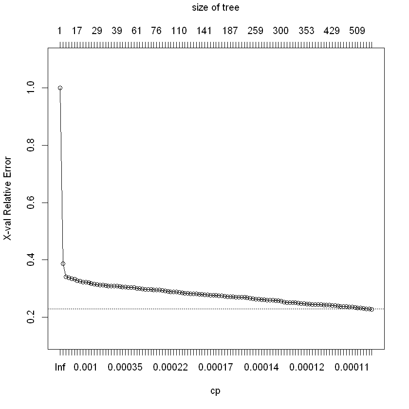

```r
plotcp(arvore)
```

E possivel perceber pelo grafico anterior que o erro cai enquanto arvore for crescendo, permitindo observar que pruning vai acabar nao sendo feito, caso utilize o cp com menor erro.

```r
# Encontrando cp com menor erro, que remete ao tamanho da árvore ideal, garantindo um pruning que diminua o erro.
melhorcp <- arvore$cptable[which.min(arvore$cptable[,"xerror"]),"CP"]
```

```r
melhorcp
```

1e-04

### Poda

A poda da árvore é realizada com o intuito de aumentar o viés da árvore e diminuir sua variância. No caso, não acarretará em mudanças na arvore de decisão, visto que o menor erro foi apresentado com a maior árvore, como pode ser visto no gráfico anterior

```r
poda <- prune(arvore, cp = melhorcp)
```

```r
pred_poda <- predict(poda, teste, type='class')
resultados[nrow(resultados)+1, ] = c("Arvore de decisao podada",
                                     mean(pred_poda != teste$answer), NA)
```

```r
resultados
```

| metodo | erro | corte |
| --- | --- | --- |
| Logistico | 0.186092507098424 | 0.54 |
| Logistico stepf 200 | 0.189500834471249 | 0.82 |
| Logistico stepb 200 | 0.189500834471249 | 0.82 |
| Ridge lambda = 0.0345 | 0.18847671066606 | 0.44 |
| Lasso lambda = 1e-04 | 0.186087088453952 | 0.54 |
| Arvore de decisao | 0.110036413290851 | NA |
| Arvore de decisao podada | 0.110036413290851 | NA |

Obs: Árvore se manteve igual e não precisou de prune. Isso ocorreu, pois o melhor valor de cp não alterou a árvore, significando que sub-árvores possuem erro maior.

### Bagging

```r
library(ipred)
```

Modo de cálculo com função bagging que é menos flexivel que randomForest, por exemplo. Setting do parâmetro coob=True para usar erro out-of-bag sample (Breiman, 1996b), e portanto, deixar menos onerosa a modelagem do ponto de vista computacional em relação à validacao cruzada.

```r
set.seed(1)
mod_bagging <- bagging(answer ~ ., data = treino, coob=TRUE, importance=TRUE)
```

```r
mod_bagging
```

```
Bagging classification trees with 25 bootstrap replications

Call: bagging.data.frame(formula = answer ~ ., data = treino, coob = TRUE,
    importance = TRUE)

Out-of-bag estimate of misclassification error:  0.0125
```

```r
pred_bag <- predict(mod_bagging, newdata = teste)
```

nbag=25

```r
resultados[nrow(resultados)+1, ] = c("Bagging",
                                     mean(pred_bag != teste$answer), NA)
```

```r
mean(pred_bag != teste$answer)
```

0.0101437024513948

```r
resultados
```

| metodo | erro | corte |
| --- | --- | --- |
| Logistico | 0.186092507098424 | 0.54 |
| Logistico stepf 200 | 0.189500834471249 | 0.82 |
| Logistico stepb 200 | 0.189500834471249 | 0.82 |
| Ridge lambda = 0.0345 | 0.18847671066606 | 0.44 |
| Lasso lambda = 1e-04 | 0.186087088453952 | 0.54 |
| Arvore de decisao | 0.110036413290851 | NA |
| Arvore de decisao podada | 0.110036413290851 | NA |
| Bagging | 0.0101437024513948 | NA |

Excelente resultado conseguido pelo metodo de bagging de apenas 1% de erro pela validação cruzada!

Vamos ver a matriz de confusão gerada

```r
m_conf <- data.frame(observado = teste$answer,
                        predito = pred_bag)


table(predito = m_conf$predito,observado = m_conf$observado)
```

```
       observado
predito     0     1
      0 91388   467
      1  1405 91288
```

```r
# Taxa de acerto
# mean(m_conf$observado == m_conf$predito)
cat("Acuracia: ", mean(m_conf$observado == m_conf$predito),"\n")

# Verdadeiro Positivo (1 - Erro Tipo II ou Sensibilidade)
cat("Sensibilidade: ", sum(m_conf$predito == 0 & m_conf$observado == 0)/sum(m_conf$observado == 0),"\n")

# Falso Positivo (Especificidade)
cat("Especificidade: ", sum(m_conf$predito == 1 & m_conf$observado == 1)/sum(m_conf$observado == 1))
```

```
Acuracia:  0.9898563
Sensibilidade:  0.9848588
Especificidade:  0.9949104
```

Pelos índices explicitados anteriormente, é perceptível que o modelo está prevendo pouco melhor casos de resposta 1 do que de resposta 0. Mas, o modelo se mostra bem balanceado e bem interessante para uso, com erro baixo e equilíbrio nas respostas (percebido nos índices de sensibilidade e especificidade)

### Bagging 2

```r
install.packages('rpart')
```

```r
library(caret)
```

```r
set.seed(1)
mod_bagging2 <- train(
  answer ~ .,
  data = treino,
  method = "treebag",
  nbagg = 1,
  oob=TRUE
)
```

### Random Forest

```r
library(randomForest)
```

Há uma extensa discussão sobre quais valores settar para mtry e ntree. Mtry é o número de parâmetros disponíveis para cada split a cada 3 nós (valor default = raiz do número de variaveis preditoras). Ntree é o número de árvores para crescer.

Na literatura, há consenso em dizer que ntree necessita ser maior para garantir estabilidade no modelo, e assim, optou-se por utilizar valor mais alto possível (pode dar erros de estouro de memória), enquanto mtry optou-se por utilizar valor default, já que autores não possuem consenso se pode ou não diferir no desempenho do modelo (de acordo com Cutler et al. (2007) e Strobl et al. (2008)).

Valor máximo de ntree que foi possível aplicar devido a custo computacional: 150

```r
set.seed(1)
mod_rf <- randomForest(answer~., data=treino,ntree=150,importance=TRUE)
```

```r
pred_rf <- predict(mod_rf , newdata = teste)
```

```r
mean(pred_rf != teste$answer)
```

0.0239558272102651

Matriz de confusão

```r
print(mod_rf)
```

```
Call:
 randomForest(formula = answer ~ ., data = treino, ntree = 150,      importance = TRUE)
               Type of random forest: classification
                     Number of trees: 150
No. of variables tried at each split: 6

        OOB estimate of  error rate: 2.53%
Confusion matrix:
       0      1 class.error
0 358667  13628  0.03660538
1   5019 360880  0.01371690
```

#### Importância de variáveis no modelo Random Forest

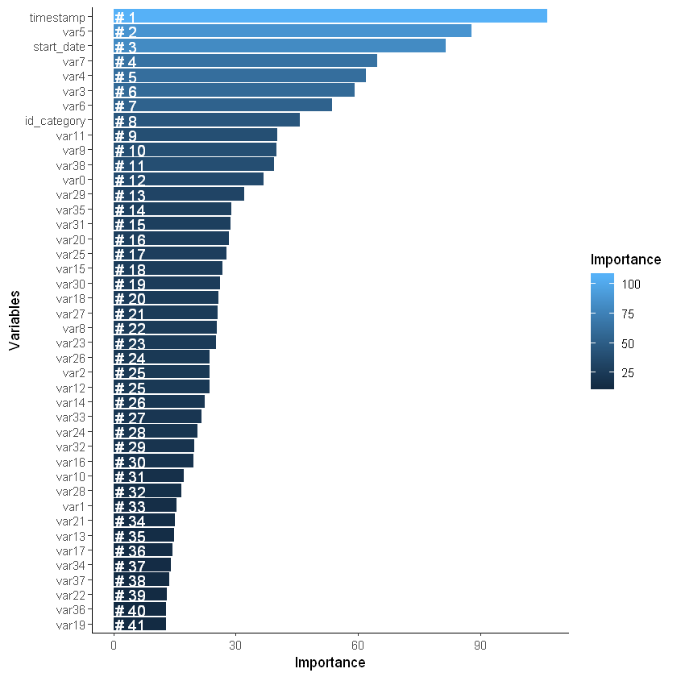

```r
library(ggplot2)
library(dplyr)
importance = importance(mod_rf)
varImportance = data.frame(Variables = row.names(importance),
 Importance =round(importance[, 'MeanDecreaseAccuracy'],2))
rankImportance= mutate(varImportance,Rank=paste('#',dense_rank(desc(Importance))))
ggplot(rankImportance,aes(x=reorder(Variables,Importance),
 y=Importance,fill=Importance))+
 geom_bar(stat='identity') +
 geom_text(aes(x = Variables, y = 0.5, label = Rank),
 hjust=0, vjust=0.55, size = 4, colour = 'white') +
 labs(x = 'Variables') +
 coord_flip() +
 theme_classic()
```

```r
metodo <- c(
'Logistico',
'Logistico stepf',
'Logistico stepb',
'Ridge lambda = 0.0345',
'Lasso lambda = 1e-04',
'Arvore de decisao',
'Arvore de decisao podada',
'Bagging',
'Random forest')
```

```r
erro <- c(
0.186092507098424,
0.189500834471249,
0.189500834471249,
0.18847671066606,
0.186087088453952,
0.110036413290851,
0.110036413290851,
0.0101437024513948,
0.023961245854737)
```

```r
corte <- c(
0.54,
0.82,
0.82,
0.44,
0.54,
NA,
NA,
NA,
NA)
```

```r
resultados <- data.frame(metodo, erro, corte)
```

```r
resultados[nrow(resultados)+1, ] = c("Random forest",
                                     mean(pred_rf != teste$answer), NA)
resultados
```

[output not shown]